# Project 3

## Optimal Cutoff

Optimal cutoff is done by applying a cut-off threshold to convert predicted probabilities in to class labels. Threshold impacts performance greatly by balancing accuracy, sensitivty, and specificity.

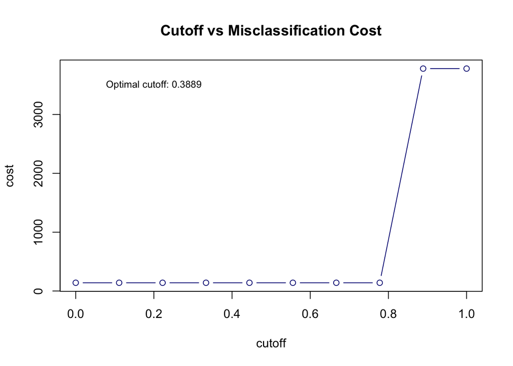

The above plot shows the optimal cutoff to be 0.3889. This threshold is used to minimize missclassification.

```r
# preditive probabilities of tree.min model.
pred.prob.min <- predict(pruned.tree.min, train.data, type = "prob")[,2]
##
cost <- NULL
cutoff <-seq(0,1, length = 10)
##
for (i in 1:10){
  pred.label <- ifelse(pred.prob.min > cutoff[i], "YES", "NO")
  FN <- sum(pred.label == "NO" & train.data$LUNG_CANCER == "YES")
  FP <- sum(pred.label == "YES" & train.data$LUNG_CANCER == "NO")
  cost[i] = 5*FP + 20*FN
}
## identify optimal cut-off
min.ID <- which(cost == min(cost))   # could have multiple minimum
optim.prob <- mean(cutoff[min.ID])   # take the average of the cut-offs
##
plot(cutoff, cost, type = "b", col = "navy",
     main = "Cutoff vs Misclassification Cost")
##
text(0.2, 3500, paste("Optimal cutoff:", round(optim.prob,4)), cex = 0.8)
```

# Ensemble Tree Methods

## Bagging (Bootstrap Regression)

Bagging is a resampling technique used to estimate the distribution of a statistic by repeatedly sampling with replacement from the original data and recalculating the statistic for each resample. An advantage of using this technique is it is non-parametric, meaning it makes no assumptions about the distribution and we do not have to assume normality. Bagging can also estimate uncertainty by providing standard errors, confidence intervals, and bias corrections.In this analysis, bagging classification will be used to create a final model.

## Hyperparameter Tuning

The hyperparameters that will be tuned are **nbagg** (number of boostrap samples), **control** (rpart, base number of parameters), **minsplit** (minimum number of observations in a node before splitting), **maxdepth** (maximum depth of the tree), and **cp** (complexity parameter).

```r
# Load necessary libraries


data$LUNG_CANCER <- as.factor(data$LUNG_CANCER)

set.seed(123)
train.idx <- createDataPartition(data$LUNG_CANCER, p = 0.7, list = FALSE)
train.data <- data[train.idx, ]
test.data <- data[-train.idx, ]

# Create a grid of hyperparameter combinations
hyper.grid <- expand.grid(
  nbagg = c(25, 50, 100),
  minsplit = c(5, 10, 20),
  maxdepth = c(5, 10, 20),
  cp = c(0.01, 0.001)
)
# Initialize a results data frame
results <- data.frame() # store values of tuned hyperparameters
best.accuracy <- 0      # store accuracy
best.params <- list()   # store best values of hyperparameter

# Loop through each hyperparameter combination
for(i in 1:nrow(hyper.grid)) {
  # Get current hyperparameters
  params <- hyper.grid[i, ]

  # Set rpart control parameters
  rpart.control <- rpart.control(
    minsplit = params$minsplit,
    maxdepth = params$maxdepth,
    cp = params$cp
  )

  # Train bagging model
  bag.model <- bagging(
    LUNG_CANCER ~ .,
    data = train.data,
    nbagg = params$nbagg,
    coob = TRUE,
    control = rpart.control
  )

  # Make predictions: default cut-off 0.5
  preds <- predict(bag.model, newdata = test.data)

  # Calculate accuracy
  cm <- confusionMatrix(preds, test.data$LUNG_CANCER)
  accuracy <- cm$overall["Accuracy"]

  # Store results
  results <- rbind(results, data.frame(
    nbagg = params$nbagg,
    minsplit = params$minsplit,
    maxdepth = params$maxdepth,
    cp = params$cp,
    Accuracy = accuracy
  ))

  # Update best parameters if current model is better
  if(accuracy > best.accuracy) {
    best.accuracy <- accuracy
    best.params <- params
  }

  # Print progress
  #cat("Completed", i, "of", nrow(hyper.grid), "combinations\n")
}
pander(best.params)
```

|  | nbagg | minsplit | maxdepth | cp |
| --- | --- | --- | --- | --- |
| **16** | 25 | 20 | 10 | 0.01 |

The values shown above are that of the hyperparameters that will be implemented to fit the final model.

```r
# Set rpart control with best parameters
best.control <- rpart.control(
  minsplit = best.params$minsplit,
  maxdepth = best.params$maxdepth,
  cp = best.params$cp
)

# Train final model
final.bag.model <- bagging(
  LUNG_CANCER ~ .,
  data = train.data,
  nbagg = best.params$nbagg,
  coob = TRUE,
  control = best.control
)

# Evaluate on test set
final.preds <- predict(final.bag.model, newdata = test.data)
final.cm <- confusionMatrix(final.preds, test.data$LUNG_CANCER)
final.cm$table
```

```
          Reference
Prediction NO YES
       NO   1   1
       YES 10  80
```

Above is the result of applying the bootstrap classification tree to the test data to help predict lung cancer outcome using the default cut-off probability. Using this confusion matrix, variable performance can then be measured.

## BAGGING vs Logistic Regression

This section will compare the Bagging Classification model to the base classification model and the logistic regression model using receiving operator characteristic (ROC) analysis and area under the curve (AUC).

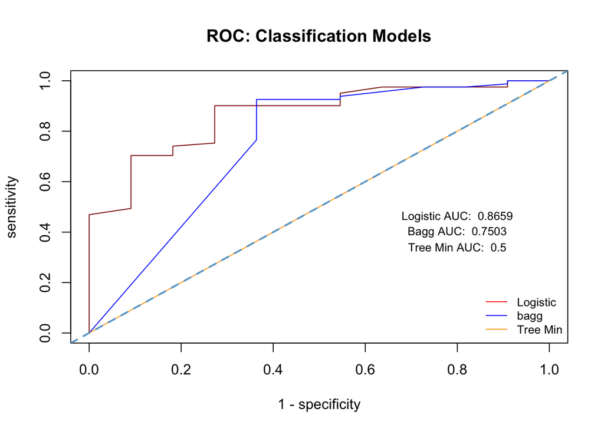

```r
 ####logistic regression
logit.fit <- glm(LUNG_CANCER ~ ., data = train.data, family = binomial)
AIC.logit <- step(logit.fit, direction = "both", trace = 0)
pred.logit <- predict(AIC.logit, test.data, type = "response")
##
# Build the initial classification tree
tree.model <- rpart(LUNG_CANCER ~ .,
                    data = train.data,
                    method = "class",   # classification tree
                    parms = list(split = "gini",  # Using Gini index
                                 # FN cost = 1, FP cost = 0.5
                                 loss = matrix(c(0, 0.5, 1, 0), nrow = 2)
                                 ),
                    control = rpart.control(minsplit = 15,  # Min 15 obs to split
                                           minbucket = 5,   # Min 7 obs in leaf
                                           # Complexity parameter
                                           cp = 0.001, # complex parameter
                                           maxdepth = 5))   # Max tree depth
###
min.cp <- tree.model$cptable[which.min(tree.model$cptable[,"xerror"]),"CP"]

# Prediction with three candidate models
pruned.tree.min <- prune(tree.model, cp = min.cp)
pred.prob.min <- predict(pruned.tree.min, test.data, type = "prob")[,2]
pred.prob.bagg <- predict(final.bag.model, newdata = test.data, type = "prob")[,2]
##
# ROC object
roc.tree.min <- roc(test.data$LUNG_CANCER, pred.prob.min)
roc.logit <- roc(test.data$LUNG_CANCER, pred.logit)
roc.bagg <- roc(test.data$LUNG_CANCER, pred.prob.bagg)
##
##
### Sen-Spe
bagg.sen <- roc.bagg$sensitivities
bagg.spe <- roc.bagg$specificities
#
tree.min.sen <- roc.tree.min$sensitivities
tree.min.spe <- roc.tree.min$specificities
#
logit.sen <- roc.logit$sensitivities
logit.spe <- roc.logit$specificities
## AUC
auc.bagg <- roc.bagg$auc
auc.tree.min <- roc.tree.min$auc
auc.logit <- roc.logit$auc
###
plot(1-logit.spe, logit.sen,
     xlab = "1 - specificity",
     ylab = "sensitivity",
     col = "darkred",
     type = "l",
     lty = 1,
     lwd = 1,
     main = "ROC: Classification Models")
lines(1-bagg.spe, bagg.sen,
      col = "blue",
      lty = 1,
      lwd = 1)
lines(1-tree.min.spe, tree.min.sen,
      col = "orange",
      lty = 1,
      lwd = 1)
abline(0,1, col = "skyblue3", lty = 2, lwd = 2)
legend("bottomright", c("Logistic", "bagg", "Tree Min"),
       lty = c(1,1,1), lwd = rep(1,3),
       col = c("red", "blue", "orange"),
       bty="n",cex = 0.8)
## annotation - AUC
text(0.8, 0.46, paste("Logistic AUC: ", round(auc.logit,4)), cex = 0.8)
text(0.8, 0.4, paste("Bagg AUC: ", round(auc.bagg,4)), cex = 0.8)
text(0.8, 0.34, paste("Tree Min AUC: ", round(auc.tree.min,4)), cex = 0.8)
```

# Random Forest

Random Forest is a method of ensemble learning that creates multiple decision trees during training and outputs the mode of classes for individual trees. For classification, the first step is splitting the data into training and testing sets. After, an initial random forest model is trained using default hyperparameters to split the data into nodes.

## Implmentation

Hyperparameter tuning will be used to increase model performance using grid search. Hyperparameters are tuned using 5-fold cross-validation. The hyperparameters are **mtry** (number of variables randomly sampled in each split), **ntree** (numbers of trees to create), **nodesize** (minimum amount of terminal nodes), and **maxnodes** (maximum amount of terminal nodes possible for each tree).

```r
data <- read.csv('https://raw.githubusercontent.com/GabbyK8/Datasets/refs/heads/main/survey%20lung%20cancer.csv')
# Convert back to factor with proper ordering
data$LUNG_CANCER <- as.factor(data$LUNG_CANCER)

set.seed(123)
train.idx <- createDataPartition(data$LUNG_CANCER, p = 0.7, list = FALSE)
train.data <- data[train.idx, ]
test.data <- data[-train.idx, ]

# cross-validation setting
k = 5
train.size <- dim(train.data)[1]  # training data size
fold.size <- floor(train.size/k)  # fold size

##
tune.grid <- expand.grid(
  mtry = c(2, 3, 4, 5),
  ntree = c(100, 300, 500),
  nodesize = c(1, 3, 5, 10),
  maxnodes = c(5, 10, 20, NULL)
)
### store hyperparameters and avg of cv AUC
results <- data.frame()
best.auc <- 0.5         # place-holder of AUC, 0.5 = random guess
best.hyp.params <- list()   # update the hyperparameter list according to the best auc

##
for (i in 1:nrow(tune.grid)){
  current.tune.params <- tune.grid[i, ]  # subset of DATA FRAME!!
  cv.auc <- rep(0,k)
  ##
  for (j in 1:k){
      cv.id <- (1 + (j-1)*fold.size):(j*fold.size)
      cv.train <- train.data[-cv.id, ]
      cv.valid <- train.data[cv.id, ]
      ##
       rf.cv <- randomForest(
                   LUNG_CANCER ~ .,
                   data = cv.train,
                   mtry = current.tune.params$mtry,
                   ntree = current.tune.params$ntree,
                   nodesize = current.tune.params$nodesize,
                   maxnodes = current.tune.params$maxnodes)
       ##
       prob.cv <- predict(rf.cv, cv.valid, type = "prob")[, "YES"]
       cv.auc[j] <- pROC::auc(pROC::roc(cv.valid$LUNG_CANCER, prob.cv))
      }
      ##
      # Average RMSE across folds
      avg.auc <- mean(cv.auc)
      ##
      # Store results: the data frame defined to store combinations of hyperparameters
      # and the resulting mean RMSEs from cross-validation
      results <- rbind(results, data.frame(
                   mtry = current.tune.params$mtry,
                   ntree = current.tune.params$ntree,
                   nodesize = current.tune.params$nodesize,
                   maxnodes = current.tune.params$maxnodes,
                   auc = avg.auc))

     # Update best parameters if current model is better
     if(avg.auc > best.auc) {
           best.auc <- avg.auc
           best.hyp.params <- current.tune.params }

}
pander(data.frame(cbind(best.hyp.params,best.auc)))    # resulting tuned hyperparameters
```

|  | mtry | ntree | nodesize | maxnodes | best.auc |
| --- | --- | --- | --- | --- | --- |
| **5** | 2 | 300 | 1 | 5 | 0.9571 |

Performance was measured using the area under the ROC curve. The tuned hyperparameters will then be used the train the random forest model.

```r
##
final.rf.cls <- randomForest(
      LUNG_CANCER ~ .,
      data = train.data,
      ntree = best.hyp.params$ntree,
      mtry = best.hyp.params$mtry,
      nodesize = best.hyp.params$nodesize,
      maxnodes = current.tune.params$maxnodes,
      importance = TRUE
     )

test.pred <- predict(final.rf.cls, test.data)
test.prob <- predict(final.rf.cls, test.data, type = "prob")
rf.roc <- roc(test.data$LUNG_CANCER, test.prob[, "YES"])
test.auc <- pROC::auc(rf.roc)
#confusionMatrix(test.pred, test.data$diabetes)
test.auc
```

```
Area under the curve: 0.9214
```

## Variable Importance

The plot below and to the left, illustrates how much the model’s accuracy decreases on average when each variable it permuted. The plot below and to the right, shows the Gini impurity, which measures how frequent a randomly chosen variable from the set would be labeled incorrectly if it’s label followed the distribution from the subset.

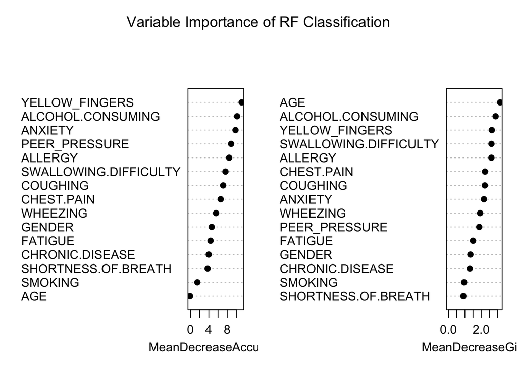

The above plots show that yellow fingers, alcohol consumption, and age are strong options for the most important variables featured in the random forest classification. However, their importance differs based on the metric used. Other variables that are important are swallowing difficulty, allergy, chest pain, coughing, and anxiety.

```r
# Variable Importance
varImpPlot(final.rf.cls, pch = 19, main = "Variable Importance of RF Classification" )
```